# Dynamic UIs & Modules

Lecture 23

Dr. Colin Rundel

# Dynamic UI

## Comparing priors

Our Beta-Binomial app has a single prior. To see how much the posterior depends on that choice we want to compare several priors, without knowing in advance how many there will be.

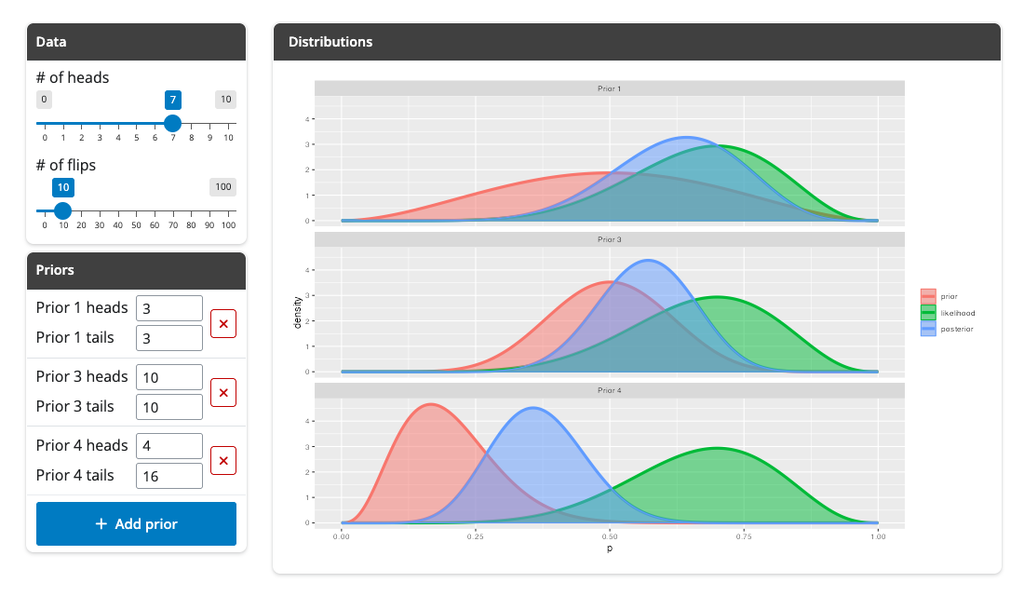

## Prior, likelihood, & posterior

As before, the plot shows a prior, likelihood, and posterior curve, now once for each prior. A helper function computes all three, with the likelihood scaled by `n + 1` so that it integrates to 1.

```r
n_sim = 501

beta_binom = function(label, a, b, x, n) {
  tibble(
    label = label,
    p = seq(0, 1, length.out = n_sim),
    prior = dbeta(p, a, b),
    likelihood = dbinom(x, n, p) * (n + 1),
    posterior = dbeta(p, a + x, b + n - x)
  ) |>
    pivot_longer(
      prior:posterior,
      names_to = "distribution", values_to = "density",
      names_transform = fct_inorder
    )
}
```

## Styling with CSS

The apps in this lecture share a small stylesheet that makes the inputs more compact. It is kept in its own file, `Lec23_app.css`, and loaded by the UI.

```r
ui = page_fillable(
  tags$head(includeCSS("Lec23_app.css")),
  ...
)
```

```css
.prior label { flex: 1; margin-bottom: 0; }
.prior input { width: 4.5rem; padding: 0.1rem 0.4rem; }
```

- `includeCSS()` reads the file and returns its contents in a `<style>` tag. The path is relative to the app’s directory.
- `tags$head()` moves that tag into the page’s `<head>`, so it takes up no space in the layout.
- The rules pick out elements by class. Most UI functions take a `class` argument, such as `card_body(class = "prior", ...)`.

## Inputs for each prior

Each prior needs its own pair of inputs and every input needs its own id. A function that builds the ids from a number lets us make as many sets of inputs as we need.

```r
prior_inputs = function(id) {
  card_body(
    numericInput(
      paste0("a_", id), paste("Prior", id, "heads"),
      min = 0, value = rpois(1, 3) + 1
    ),
    numericInput(
      paste0("b_", id), paste("Prior", id, "tails"),
      min = 0, value = rpois(1, 3) + 1
    )
  )
}
```

`prior_inputs(2)` creates the inputs `a_2` and `b_2`. The server will not know the number ahead of time, so it cannot write `input$a_2` and has to build the name and use something like `input[[paste0("a_", id)]]`.

## A first attempt with `renderUI()`

```r
card(
  card_header("Priors"),
  uiOutput("priors"),
  card_footer(
    actionButton("add", "Add prior")
  )
)
```

```r
output$priors = renderUI({
  map(
    seq_len(input$add), prior_inputs
  )
})
```

`input$add` counts clicks, so each click re-runs `renderUI()` and draws the inputs for priors `1` to `input$add`.

## Reading the inputs

The reactive builds each prior’s ids and reads its inputs with `input[[...]]`. A new prior’s inputs start as `NULL`, hence the `req()`.

```r
d = reactive({
  map(
    seq_len(input$add),
    \(id) {
      a = input[[paste0("a_", id)]]
      b = input[[paste0("b_", id)]]
      req(a, b)

      beta_binom(paste("Prior", id), a, b, input$x, input$n)
    }
  ) |>
    list_rbind()
})
```

## The complete app

The full script is available as `Lec23_app1.R`.

```r
library(tidyverse)
library(shiny)
library(bslib)

n_sim = 501

beta_binom = function(label, a, b, x, n) {
  tibble(
    label = label,
    p = seq(0, 1, length.out = n_sim),
    prior = dbeta(p, a, b),
    likelihood = dbinom(x, n, p) * (n + 1),
    posterior = dbeta(p, a + x, b + n - x)
  ) |>
    pivot_longer(
      prior:posterior,
      names_to = "distribution", values_to = "density",
      names_transform = fct_inorder
    )
}

prior_inputs = function(id) {
  card_body(
    class = "prior",
    numericInput(
      paste0("a_", id), paste("Prior", id, "heads"),
      min = 0, value = rpois(1, 3) + 1
    ),
    numericInput(
      paste0("b_", id), paste("Prior", id, "tails"),
      min = 0, value = rpois(1, 3) + 1
    )
  )
}

ui = page_fillable(
  title = "Beta-Binomial Prior Comparison",
  tags$head(includeCSS("Lec23_app.css")),
  layout_columns(
    col_widths = c(3, 9),
    div(
      class = "controls overflow-auto px-1 pb-1",
      card(
        card_header("Data", class = "text-bg-secondary"),
        sliderInput("x", "# of heads", min = 0, max = 100, value = 7),
        sliderInput("n", "# of flips", min = 0, max = 100, value = 10)
      ),
      card(
        card_header("Priors", class = "text-bg-secondary"),
        uiOutput("priors"),
        card_footer(
          actionButton(
            "add", "Add prior", icon = icon("plus"),
            class = "btn-primary w-100"
          )
        )
      )
    ),
    card(
      card_header("Distributions", class = "text-bg-secondary"),
      plotOutput("plot")
    )
  )
)

server = function(input, output, session) {
  observe({
    updateSliderInput(session, "x", max = input$n)
  }) |>
    bindEvent(input$n)

  output$priors = renderUI({
    map(seq_len(input$add), prior_inputs)
  })

  d = reactive({
    map(
      seq_len(input$add),
      \(id) {
        a = input[[paste0("a_", id)]]
        b = input[[paste0("b_", id)]]
        req(a, b)

        beta_binom(paste("Prior", id), a, b, input$x, input$n)
      }
    ) |>
      list_rbind()
  })

  output$plot = renderPlot({
    req(nrow(d()) > 0)

    ggplot(d(), aes(x = p, y = density, color = distribution)) +
      geom_line(linewidth = 1.5) +
      geom_ribbon(aes(ymax = density, fill = distribution), ymin = 0, alpha = 0.5) +
      facet_wrap(vars(label), ncol = 1) +
      labs(color = NULL, fill = NULL)
  })
}

shinyApp(ui = ui, server = server)
```

## Limitations of `renderUI()`

The app runs, but it is frustrating to use.

- `renderUI()` rebuilds its whole output every time it runs.
  - Each click replaces all of the inputs, including the ones already on the page,
  - so every prior is reset to new starting values.
- The click count is the server’s only record of what is on the page.
- We can only add prior’s we can’t remove them

What we need is a way to add or remove a single prior and leave the rest of the page alone.

# Example 2

## `reactiveVal()` & `reactiveValues()`

An input changes when the user changes it and a `reactive()` changes when it is recalculated. Neither can be set by our own server code, which is what these two are for.

```r
count = reactiveVal(0)

count()
count(count() + 1)
```

```r
rv = reactiveValues(count = 0)

rv$count
rv$count = rv$count + 1
```

- `reactiveVal()` holds a single value. Calling it with no arguments reads the value and calling it with one argument replaces it.
- `reactiveValues()` holds a named list of values that are read and set with `$`, in the same way as `input`.
- Both behave like inputs. A reactive or observer that reads one depends on it, and setting a new value invalidates everything that has read it.
- A value can be set from anywhere, but an observer is the right place. A `reactive()` or `render*()` function only runs when its result is needed, so a value set inside one may not change when we expect it to.

## `insertUI()` & `removeUI()`

These functions add and remove pieces of UI from the server without touching anything else on the page.

```r
insertUI(selector = "#priors", where = "beforeEnd", ui = prior_inputs(1))
```

```r
removeUI(selector = "#prior_1")
```

## Adding a prior

In the UI the `uiOutput()` is replaced by an empty `div` with the id `priors`.

```r
card(
  card_header("Priors"),
  div(id = "priors"),
  card_footer(
    actionButton("add", "Add prior")
  )
)
```

```r
ids = reactiveVal(integer())

observe({
  id = input$add

  insertUI(
    "#priors", where = "beforeEnd",
    ui = prior_inputs(id)
  )
  ids(c(ids(), id))
}) |>
  bindEvent(input$add)
```

- The click count is different for every click, so it works as a unique id.
- `ids` is the server’s only record of which priors are on the page.
- `bindEvent()` makes the observer run only when `input$add` changes (and not at startup).
  - Without it the observer would also depend on `ids()`.

## Removing a prior

Each prior gets an id and a remove button,

```r
card_body(
  id = paste0("prior_", id),
  ...,
  actionButton(paste0("remove_", id), NULL, icon = icon("xmark"))
)
```

The remove button then needs an observer to make it functional,

```r
observe({
  removeUI(paste0("#prior_", id))
  ids(setdiff(ids(), id))
}) |>
  bindEvent(input[[paste0("remove_", id)]], once = TRUE)
```

but where do we define this? The code for both parts needs to know what the current `id` is.

## Adding & removing together

The answer is the same - both steps need to occur in our `input$add` observer.

```r
ids = reactiveVal(integer())

observe({
  id = input$add

  insertUI("#priors", where = "beforeEnd", ui = prior_inputs(id))
  ids(c(ids(), id))

  observe({
    removeUI(paste0("#prior_", id))
    ids(setdiff(ids(), id))
  }) |>
    bindEvent(input[[paste0("remove_", id)]], once = TRUE)
}) |>
  bindEvent(input$add)
```

- Every click creates a new inner observer with its own copy of `id`, so each remove button removes only its own prior.
- The remove button’s input does not exist until its UI has been inserted. `bindEvent()` ignores it while it is `NULL`.

## Updating the reactive

The reactive now iterates over `ids()` in place of `seq_len(input$add)`, so a removed prior also drops out of the plot.

```r
d = reactive({
  map(
    ids(),
    \(id) {
      ...
    }
  ) |>
    list_rbind()
})
```

## The complete app

The full script is available as `Lec23_app2.R`.

```r
library(tidyverse)
library(shiny)
library(bslib)

n_sim = 501

beta_binom = function(label, a, b, x, n) {
  tibble(
    label = label,
    p = seq(0, 1, length.out = n_sim),
    prior = dbeta(p, a, b),
    likelihood = dbinom(x, n, p) * (n + 1),
    posterior = dbeta(p, a + x, b + n - x)
  ) |>
    pivot_longer(
      prior:posterior,
      names_to = "distribution", values_to = "density",
      names_transform = fct_inorder
    )
}

prior_inputs = function(id) {
  card_body(
    id = paste0("prior_", id),
    class = "prior",
    numericInput(
      paste0("a_", id), paste("Prior", id, "heads"),
      min = 0, value = rpois(1, 3) + 1
    ),
    numericInput(
      paste0("b_", id), paste("Prior", id, "tails"),
      min = 0, value = rpois(1, 3) + 1
    ),
    actionButton(
      paste0("remove_", id), NULL, icon = icon("xmark"),
      class = "btn-sm btn-outline-danger"
    )
  )
}

ui = page_fillable(
  title = "Beta-Binomial Prior Comparison",
  tags$head(includeCSS("Lec23_app.css")),
  layout_columns(
    col_widths = c(3, 9),
    div(
      class = "controls overflow-auto px-1 pb-1",
      card(
        card_header("Data", class = "text-bg-secondary"),
        sliderInput("x", "# of heads", min = 0, max = 100, value = 7),
        sliderInput("n", "# of flips", min = 0, max = 100, value = 10)
      ),
      card(
        card_header("Priors", class = "text-bg-secondary"),
        div(id = "priors"),
        card_footer(
          actionButton(
            "add", "Add prior", icon = icon("plus"),
            class = "btn-primary w-100"
          )
        )
      )
    ),
    card(
      card_header("Distributions", class = "text-bg-secondary"),
      plotOutput("plot")
    )
  )
)

server = function(input, output, session) {
  observe({
    updateSliderInput(session, "x", max = input$n)
  }) |>
    bindEvent(input$n)

  ids = reactiveVal(integer())

  observe({
    id = input$add

    insertUI("#priors", where = "beforeEnd", ui = prior_inputs(id))
    ids(c(ids(), id))

    observe({
      removeUI(paste0("#prior_", id))
      ids(setdiff(ids(), id))
    }) |>
      bindEvent(input[[paste0("remove_", id)]], once = TRUE)
  }) |>
    bindEvent(input$add)

  d = reactive({
    map(
      ids(),
      \(id) {
        a = input[[paste0("a_", id)]]
        b = input[[paste0("b_", id)]]
        req(a, b)

        beta_binom(paste("Prior", id), a, b, input$x, input$n)
      }
    ) |>
      list_rbind()
  })

  output$plot = renderPlot({
    req(nrow(d()) > 0)

    ggplot(d(), aes(x = p, y = density, color = distribution)) +
      geom_line(linewidth = 1.5) +
      geom_ribbon(aes(ymax = density, fill = distribution), ymin = 0, alpha = 0.5) +
      facet_wrap(vars(label), ncol = 1) +
      labs(color = NULL, fill = NULL)
  })
}

shinyApp(ui = ui, server = server)
```

## What we ended up with

The app works, but the code for a single prior is hard to follow and harder to reuse.

- The naming scheme (`prior_1`, `a_1`, `b_1`, `remove_1`) is repeated by hand in the UI function, both observers, and the reactive.
- The logic for one prior is spread over four separate places in the app.
- Every id lives in one shared namespace, so nothing stops another part of the app from also using `a_1`.
- Using these inputs in a second app means copying all of these pieces and keeping them in sync.

# Modules

## Shiny modules

A module is a pair of functions that together describe one piece of an app, such as the inputs for a single prior.

- The module UI function takes an `id` and returns UI, like `prior_inputs()` did.
- The module server function takes the same `id` and holds the server code for that UI.
- Everything inside the module is namespaced by the `id`. The module’s code refers to `input$a`, while the rest of the app sees that input as `prior_1-a`.

A module can then be used several times in one app, each time with a different `id`, without any of the copies interfering with each other.

## `NS()`

Namespacing is nothing more than a prefix on the id. `NS()` returns a function that adds the prefix.

```r
ns = NS("prior_1")
```

```r
ns("a")
```

```
[1] "prior_1-a"
```

```r
ns("remove")
```

```
[1] "prior_1-remove"
```

A module UI function wraps every input and output id in `ns()`. Leaving one out is the most common mistake with modules. The app still runs, but the module’s server never sees that input.

## Module UI

By convention the function is named `*_ui()` and `id` is its first argument. Other arguments, like `label` here, are up to us.

```r
prior_ui = function(id, label) {
  ns = NS(id)

  card_body(
    id = ns("body"),
    numericInput(ns("a"), paste(label, "heads"), min = 0, value = rpois(1, 3) + 1),
    numericInput(ns("b"), paste(label, "tails"), min = 0, value = rpois(1, 3) + 1),
    actionButton(ns("remove"), NULL, icon = icon("xmark"))
  )
}
```

## Module server

```r
prior_server = function(id, label, x, n) {
  moduleServer(id, function(input, output, session) {
    reactive({
      req(input$a, input$b)

      beta_binom(label, input$a, input$b, x(), n())
    })
  })
}
```

- The app’s `input$x` is not visible here. Anything the module needs is passed in as a reactive and read as `x()`.
- The inner function’s value is returned to the caller.

## Using a module

Call each function once per copy, with matching ids.

```r
ui = page_fillable(
  layout_columns(
    card(
      card_header("Priors"),
      prior_ui("prior_1", "Prior 1"),
      prior_ui("prior_2", "Prior 2")
    ),
    plotOutput("plot")
  )
)

server = function(input, output, session) {
  x = reactive(input$x)
  n = reactive(input$n)
  prior_1 = prior_server("prior_1", "Prior 1", x, n)
  prior_2 = prior_server("prior_2", "Prior 2", x, n)

  d = reactive(bind_rows(prior_1(), prior_2()))
  ...
}
```

## Modules & dynamic UI

A module server can be started at any time. Each click inserts a new copy of the UI and starts its server.

```r
priors = reactiveVal(list())

observe({
  id = paste0("prior_", input$add)
  label = paste("Prior", input$add)

  insertUI("#priors", where = "beforeEnd", ui = prior_ui(id, label))
  prior = prior_server(id, label, x = reactive(input$x), n = reactive(input$n))
  priors(c(priors(), prior))
}) |>
  bindEvent(input$add)

d = reactive({
  map(priors(), \(prior) prior()) |>
    list_rbind()
})
```

## A module that removes itself

```r
moduleServer(id, function(input, output, session) {
  removed = reactiveVal(FALSE)

  observe({
    removeUI(paste0("#", session$ns("body")))
    removed(TRUE)
  }) |>
    bindEvent(input$remove, once = TRUE)

  reactive({
    if (removed()) return(NULL)
    ...
  })
})
```

- `input$remove` is namespaced for us but a CSS selector is not. `session$ns()` is the module’s own `NS()` function, which gives the full id of the card body.
- Shiny cannot shut down a module’s server. After removal its reactive stays in `priors()` and returns `NULL`, which `list_rbind()` drops.

## The complete app

The full script is available as `Lec23_app3.R`.

```r
library(tidyverse)
library(shiny)
library(bslib)

n_sim = 501

beta_binom = function(label, a, b, x, n) {
  tibble(
    label = label,
    p = seq(0, 1, length.out = n_sim),
    prior = dbeta(p, a, b),
    likelihood = dbinom(x, n, p) * (n + 1),
    posterior = dbeta(p, a + x, b + n - x)
  ) |>
    pivot_longer(
      prior:posterior,
      names_to = "distribution", values_to = "density",
      names_transform = fct_inorder
    )
}

prior_ui = function(id, label) {
  ns = NS(id)

  card_body(
    id = ns("body"),
    class = "prior",
    numericInput(ns("a"), paste(label, "heads"), min = 0, value = rpois(1, 3) + 1),
    numericInput(ns("b"), paste(label, "tails"), min = 0, value = rpois(1, 3) + 1),
    actionButton(
      ns("remove"), NULL, icon = icon("xmark"),
      class = "btn-sm btn-outline-danger"
    )
  )
}

prior_server = function(id, label, x, n) {
  moduleServer(id, function(input, output, session) {
    removed = reactiveVal(FALSE)

    observe({
      removeUI(paste0("#", session$ns("body")))
      removed(TRUE)
    }) |>
      bindEvent(input$remove, once = TRUE)

    reactive({
      if (removed()) return(NULL)
      req(input$a, input$b)

      beta_binom(label, input$a, input$b, x(), n())
    })
  })
}

ui = page_fillable(
  title = "Beta-Binomial Prior Comparison",
  tags$head(includeCSS("Lec23_app.css")),
  layout_columns(
    col_widths = c(3, 9),
    div(
      class = "controls overflow-auto px-1 pb-1",
      card(
        card_header("Data", class = "text-bg-secondary"),
        sliderInput("x", "# of heads", min = 0, max = 100, value = 7),
        sliderInput("n", "# of flips", min = 0, max = 100, value = 10)
      ),
      card(
        card_header("Priors", class = "text-bg-secondary"),
        div(id = "priors"),
        card_footer(
          actionButton(
            "add", "Add prior", icon = icon("plus"),
            class = "btn-primary w-100"
          )
        )
      )
    ),
    card(
      card_header("Distributions", class = "text-bg-secondary"),
      plotOutput("plot")
    )
  )
)

server = function(input, output, session) {
  observe({
    updateSliderInput(session, "x", max = input$n)
  }) |>
    bindEvent(input$n)

  priors = reactiveVal(list())

  observe({
    id = paste0("prior_", input$add)
    label = paste("Prior", input$add)

    insertUI("#priors", where = "beforeEnd", ui = prior_ui(id, label))
    prior = prior_server(id, label, x = reactive(input$x), n = reactive(input$n))
    priors(c(priors(), prior))
  }) |>
    bindEvent(input$add)

  d = reactive({
    map(priors(), \(prior) prior()) |>
      list_rbind()
  })

  output$plot = renderPlot({
    req(nrow(d()) > 0)

    ggplot(d(), aes(x = p, y = density, color = distribution)) +
      geom_line(linewidth = 1.5) +
      geom_ribbon(aes(ymax = density, fill = distribution), ymin = 0, alpha = 0.5) +
      facet_wrap(vars(label), ncol = 1) +
      labs(color = NULL, fill = NULL)
  })
}

shinyApp(ui = ui, server = server)
```

## Working with modules

- Name the pair `*_ui()` and `*_server()`, and keep the two functions together. Files in an app’s `R/` folder are sourced automatically, so `R/prior.R` is a good home for them.
- Pass reactives into a module without calling them, as `x = reactive(input$x)` or `x = d`. Passing `input$x` hands over a single value that never updates.
- Return a reactive, or a list of reactives, for anything the rest of the app needs. Avoid reaching into a module’s inputs from outside via `input[["prior_1-a"]]`.
- Modules can contain other modules. Inside a module the ids are relative, so a nested module is called with a plain id in the server and with `ns("id")` in the UI.
- A module server can be tested without a browser using `testServer()`.

## Modules in the wild

Many packages ship their Shiny components as modules, so adding one to an app is a pair of function calls.

| Package | Module | What it provides |
| --- | --- | --- |
| `esquisse` | `esquisse_ui()`, `esquisse_server()` | A drag and drop `ggplot2` builder |
| `datamods` | `import_ui()`, `import_server()` | Importing data from a file, URL, or pasted text |
| `datamods` | `filter_data_ui()`, `filter_data_server()` | Interactive filtering of a data frame |
| `shinyauthr` | `loginUI()`, `loginServer()` | A login form and user authentication |
| `shinyWidgets` | `selectizeGroupUI()`, `selectizeGroupServer()` | A group of linked select inputs |

# Shiny for Python

## The same tools in Python

Everything in this lecture has a direct counterpart in Shiny for Python.

| R | Python |
| --- | --- |
| `uiOutput()`, `renderUI()` | `ui.output_ui()`, `@render.ui` |
| `insertUI()`, `removeUI()` | `ui.insert_ui()`, `ui.remove_ui()` |
| `reactiveVal()` | `reactive.value()` |
| `observe()` with `bindEvent()` | `@reactive.effect` with `@reactive.event()` |
| `input[[id]]` | `input[id]()` |
| `NS()` in a UI function | `@module.ui` |
| `moduleServer()` | `@module.server` |
| `session$ns()` | `session.ns()` |
| `includeCSS()` | `ui.include_css()` |

There is no `reactiveValues()`. Use several `reactive.value()` objects, or one that holds a dictionary.

## `reactive.value()`

A `reactive.value()` is read by calling it and replaced with its `set()` method.

```python
priors = reactive.value([])

@reactive.effect
@reactive.event(input.add)
def _():
    id = f"prior_{input.add()}"
    label = f"Prior {input.add()}"

    ui.insert_ui(prior_ui(id, label), selector="#priors", where="beforeEnd")
    prior = prior_server(id, label, x=input.x, n=input.n)
    priors.set([*priors(), prior])
```

- `set()` only invalidates when it is given a different object. Appending to the list in place would change nothing, so we build a new list.
- `ui.insert_ui()` and `ui.remove_ui()` take the same `selector` and `where` arguments as the R functions.

## Module UI & server

```python
@module.ui
def prior_ui(label):
    return ui.card_body(
        ui.input_numeric("a", f"{label} heads", min=0, value=np.random.poisson(3) + 1),
        ui.input_numeric("b", f"{label} tails", min=0, value=np.random.poisson(3) + 1),
        ui.input_action_button("remove", "✕"),
        id=module.resolve_id("body"),
    )

@module.server
def prior_server(input, output, session, label, x, n):
    @reactive.calc
    def d():
        req(input.a(), input.b())
        return beta_binom(label, input.a(), input.b(), x(), n())

    return d
```

- The decorators add `id` as the first argument of both functions. Input and output ids inside `@module.ui` are namespaced for us, with no `ns()` calls.
- Any other id still has to be namespaced by hand, with `module.resolve_id()` in the UI and `session.ns()` in the server.

## The complete app

The full script is available as `Lec23_app.py`.

```python
from pathlib import Path

import numpy as np
import pandas as pd
import seaborn as sns
from scipy import stats
from shiny import App, module, reactive, render, req, ui

n_sim = 501

dist_colors = {"prior": "#dc3545", "likelihood": "#198754", "posterior": "#0d6efd"}


def beta_binom(label, a, b, x, n):
    return (
        pd.DataFrame({"label": label, "p": np.linspace(0, 1, n_sim)})
        .assign(
            prior=lambda df: stats.beta.pdf(df.p, a, b),
            likelihood=lambda df: stats.beta.pdf(df.p, x + 1, n - x + 1),
            posterior=lambda df: stats.beta.pdf(df.p, a + x, b + n - x),
        )
        .melt(id_vars=["label", "p"], var_name="distribution", value_name="density")
    )


@module.ui
def prior_ui(label):
    return ui.card_body(
        ui.input_numeric("a", f"{label} heads", min=0, value=np.random.poisson(3) + 1),
        ui.input_numeric("b", f"{label} tails", min=0, value=np.random.poisson(3) + 1),
        ui.input_action_button("remove", "✕", class_="btn-sm btn-outline-danger"),
        id=module.resolve_id("body"),
        class_="prior",
    )


@module.server
def prior_server(input, output, session, label, x, n):
    removed = reactive.value(False)

    @reactive.effect
    @reactive.event(input.remove)
    def _():
        ui.remove_ui(f"#{session.ns('body')}")
        removed.set(True)

    @reactive.calc
    def d():
        if removed():
            return None
        req(input.a(), input.b())

        return beta_binom(label, input.a(), input.b(), x(), n())

    return d


app_ui = ui.page_fillable(
    ui.include_css(Path(__file__).parent / "Lec23_app.css"),
    ui.layout_columns(
        ui.div(
            ui.card(
                ui.card_header("Data", class_="text-bg-secondary"),
                ui.input_slider("x", "# of heads", min=0, max=100, value=7),
                ui.input_slider("n", "# of flips", min=0, max=100, value=10),
            ),
            ui.card(
                ui.card_header("Priors", class_="text-bg-secondary"),
                ui.div(id="priors"),
                ui.card_footer(
                    ui.input_action_button(
                        "add", "+ Add prior", class_="btn-primary w-100"
                    )
                ),
            ),
            class_="controls overflow-auto px-1 pb-1",
        ),
        ui.card(
            ui.card_header("Distributions", class_="text-bg-secondary"),
            ui.output_plot("plot"),
        ),
        col_widths=(3, 9),
    ),
    title="Beta-Binomial Prior Comparison",
)


def server(input, output, session):
    @reactive.effect
    def _():
        ui.update_slider("x", max=input.n())

    priors = reactive.value([])

    @reactive.effect
    @reactive.event(input.add)
    def _():
        id = f"prior_{input.add()}"
        label = f"Prior {input.add()}"

        ui.insert_ui(prior_ui(id, label), selector="#priors", where="beforeEnd")
        prior = prior_server(id, label, x=input.x, n=input.n)
        priors.set([*priors(), prior])

    @reactive.calc
    def d():
        dfs = [prior() for prior in priors()]
        req(any(df is not None for df in dfs))

        return pd.concat(dfs)

    @render.plot
    def plot():
        g = sns.relplot(
            d(), x="p", y="density", hue="distribution", row="label",
            kind="line", palette=dist_colors,
        )
        for ax in g.axes.flat:
            for line in ax.lines:
                ax.fill_between(*line.get_data(), color=line.get_color(), alpha=0.3)

        return g.figure


app = App(app_ui, server)
```

# Summary

## Takeaways

- `renderUI()` rebuilds everything it returns, which resets any inputs it contains. `insertUI()` and `removeUI()` change one piece of the page and leave the rest alone.
- UI that is added while the app runs needs unique ids and a record on the server of what currently exists, typically kept in a `reactiveVal()`. Inputs with generated ids are read with `input[[id]]`.
- Doing this by pasting ids together works, but the naming scheme ends up repeated throughout the app.
- A module pairs a UI function with a server function that share an `id`. `NS()` prefixes the ids in the UI and `moduleServer()` gives the server a view of only its own inputs and outputs.
- Reactives go into a module as arguments and come out as its return value.
- Module servers can be started from an observer, which makes modules a good fit for UI that is created on demand.

## Learning more

- [Mastering Shiny - Dynamic UI](https://mastering-shiny.org/action-dynamic.html), including `insertUI()` and `removeUI()`
- [Mastering Shiny - Shiny modules](https://mastering-shiny.org/scaling-modules.html), with many more examples of module inputs and outputs
- [Modularizing Shiny app code](https://shiny.posit.co/r/articles/improve/modules/) from the Shiny documentation
- Reference pages for [`insertUI()`](https://shiny.posit.co/r/reference/shiny/latest/insertui.html), [`moduleServer()`](https://shiny.posit.co/r/reference/shiny/latest/moduleserver.html), and [`NS()`](https://shiny.posit.co/r/reference/shiny/latest/ns.html)
- [Mastering Shiny - Testing](https://mastering-shiny.org/scaling-testing.html) for `testServer()`